# Detecting pedestrians in the wild

## Get the dataset

```python
# Working with the MIT People dataset
# The file should be at /data/pedestrians128x64.tar.gz

datadir = "data"
dataset = "pedestrians128x64"
datafile = "%s/%s.tar.gz"%(datadir, dataset)
```

```python
# Extract all files into their own subdirectories
extractdir = "%s/%s"%(datadir, dataset)
```

```python
# Doing it with Python
def extract_tar(filename):
    try:
        import tarfile
    except ImportError:
        raise ImportError("You do not have tarfile installed."
                         "Try unzipping the file outside of "
                         "Python.")
    tar = tarfile.open(datafile)
    tar.extractall(path=extractdir)
    tar.close()
    print("%s successfully extracted to %s"%(datafile, extractdir))
```

```python
extract_tar(datafile)
# todo: Check why it unzips to
# data/pedestrians128x64/pedestrians128x64
# Moving the files one dir up fixes the problem
```

```
data/pedestrians128x64.tar.gz successfully extracted to data/pedestrians128x64
```

```python
# The dataset comes with 924 color images of pedestrians
# scaled to 64x128 px and aligned so that the body is in
# the center of the frame

import cv2
import matplotlib.pyplot as plt
%matplotlib inline
```

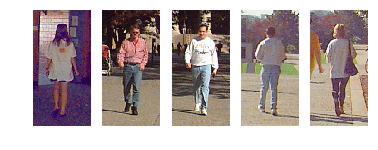

```python
for i in range(5):
    filename = "%s/per0010%d.ppm"%(extractdir, i)
    img = cv2.imread(filename)
    plt.subplot(1, 5, i+1)
    plt.imshow(cv2.cvtColor(img, cv2.COLOR_BGR2RGB))
    plt.axis('off')
```

## Taking a glimpse at the histogram of oriented gradients

> The essential idea behind HOG features is that the local shapes and appearance of objects within an image can be described by the distribution of edge directions. The image is divided into small connected regions, within which a histogram of gradient directions (or edge directions) is compiled. Then, the descriptor is assembled by concatenating the different histograms.

```python
# HOG: Histogram of oriented gradients
win_size = (48,96) # Detection window size
block_size = (16,16) # How large each box is
block_stride = (8,8)
cell_size = (8,8) # How many pixels from one cell to the next
num_bins = 9
hog = cv2.HOGDescriptor(win_size, block_size, block_stride,\
                       cell_size, num_bins)
```

```python
# Call the hog on our data samples
# Build a dataset of positive samples X_pos by picking
# images at random

# There's no image 00000, start the range from 1

import numpy as np
import random
random.seed(42)
X_pos = []
for i in random.sample(range(900), 400):
    filename = "%s/per%05d.ppm"%(extractdir, i)
    img = cv2.imread(filename)
    if img is None:
        print('Could not find image %s'%filename)
        continue
    X_pos.append(hog.compute(img, (64, 64)))
```

```
Could not find image data/pedestrians128x64/per00000.ppm
```

```python
# Feature matrix should be float32,
# Labels should be int32
X_pos = np.array(X_pos, dtype=np.float32)
y_pos = np.ones(X_pos.shape[0], dtype=np.int32)
X_pos.shape, y_pos.shape
# 399 training samples, each with 1980 feature values
```

```
((399, 1980, 1), (399,))
```

## Generating negatives

> The real challenge, however, is to come up with the perfect example of a non-pedestrian. After all, it's easy to think of example images of pedestrians. But what is the opposite of a pedestrian?

How to generate an example of a non-pedestrian? A good 1st approach: assemble a dataset of imagesthat look like the images of the positive class but do not contain pedestrians.

Urban and Natural Scene dataset, Computational Visual Cognition Lab, MIT Sample data `(data/pedestrians_neg)` from the author

```python
negdir = "%s/pedestrians_neg" % datadir
```

> In order to use them as samples from a negative class that go together with our images of pedestrians; wer need to make sure that all images have the same pixel size.

> Moreover, the things depicted should roughly be at the same scale. Thus, we loop through all the images and cut out a 64x128 ROI

```python
import os
hroi = 128
wroi = 64
X_neg = []
for negfile in os.listdir(negdir):
    filename = '%s/%s'%(negdir, negfile)
    # To bring images to roughly same scale as pedestrians
    img = cv2.imread(filename)
    img = cv2.resize(img, (512, 512))
    # Cut the ROI, choose at random
    # Arbitrary no. of times
    for j in range(5):
        rand_y = random.randint(0, img.shape[0] - hroi)
        rand_x = random.randint(0, img.shape[1] - wroi)
        roi = img[rand_y:rand_y+hroi, rand_x:rand_x + wroi, :]
        X_neg.append(hog.compute(roi, (64, 64)))
```

```python
# We almost forgot to convert to 32bit float
# and the target label of all these should be -1
# (negative class)

X_neg = np.array(X_neg, dtype=np.float32)
y_neg = -np.ones(X_neg.shape[0], dtype=np.int32)
X_neg.shape, y_neg.shape

# The book says it should be ((250, 1980, 1),(250,))
# Why isn't it so?
#
# : Because you didn't write the code correctly in
# : the last cell, dummy -- 2018-11-22
```

```
((250, 1980, 1), (250,))
```

```python
# Concatenate  all positive and negative examples
# to a single dataset X
# which will be then split

X = np.concatenate((X_pos, X_neg))
y = np.concatenate((y_pos, y_neg))
```

```python
from sklearn import model_selection as ms
X_train, X_test, y_train, y_test, = ms.train_test_split(\
    X, y, test_size=0.2, random_state=42)
```

> A common and painful mistake is to accidentally include a negative sample that does indeed contain a pedestrian somewhere. Make sure this does not happen to you!

## Implementing the support vector machine

```python
# Implementing the Support Vector Machine
# It's done in a function so that it's easier to repeat
def train_svm(X_train, y_train):
    svm = cv2.ml.SVM_create()
    svm.train(X_train, cv2.ml.ROW_SAMPLE, y_train)
    return svm
```

```python
# We don't specify whether the feature matrix is
# the training or the test set. It doesn't matter
# as long as they have the right format

def score_svm(svm, X, y):
    from sklearn import metrics
    _, y_pred = svm.predict(X)
    return metrics.accuracy_score(y, y_pred)
```

```python
# Train and score the SVM
svm = train_svm(X_train, y_train)
```

```python
score_svm(svm, X_train, y_train)
# 1.0
```

```
1.0
```

```python
score_svm(svm, X_test, y_test)
# Book says
#0.64615384615384619
```

```
0.6461538461538462
```

Book says:

> thanks to the HOG feature descritor, we make no mistake on the training set. However, our generalization performance is quite abysmal (64.6 percent), as it is much less than the training performance (100 percent). This is an indication that the model is **overfitting** the data. The fact that it is performing way better on the training set than the test set means that the model has resorted to memorizing the training samples, rather than trying to abstract it into a meaningful decision rule. What can we do to improve the model performance?

## Bootstrapping the model

> This idea was actually applied in one of the first papers on using SVMs in combination with HOG features for pedestrian detection. So let's pay a little tribute to the pioneers and try to understand what they did.

> Their idea was quite simple. After training the SVM on the training set, they scored the model and found that the model produced some false positives. Remember that false positive means that the model predicted a positive (+) for a sample that was really a negative (-). In our context, this would mean the SVM falsely believed an image to contain a pedestrian. If this happens for a particular image in the dataset, this example is clearly troublesome. Hence, we should add it to the training set and retrain the SVM with the additional troublemaker, so that the algorithm can learn to classify that one correctly. This procedure can be repeated until the SVM gives satisfactory performance.

```python
# Bootstrapping
# We will repeat the training procedure a max 3 times
# Then, identify false positives and add them to the next
# training set

# 1. Train and score the model
score_train = []
score_test = []
for j in range(3):
    svm = train_svm(X_train, y_train)
    score_train.append(score_svm(svm, X_train, y_train))
    score_test.append(score_svm(svm, X_test, y_test))
    # 2. find false positives
    _, y_pred = svm.predict(X_test)
    false_pos = np.logical_and((y_test.ravel() == -1),\
                              (y_pred.ravel() == 1))
    if not np.any(false_pos):
        print('No more false positives: done')
        break
    # 3. append false positives to training set, repeat
    X_train = np.concatenate((X_train, X_test[false_pos, :]),\
                            axis=0)
    y_train = np.concatenate((y_train, y_test[false_pos]),\
                            axis=0)
```

```
No more false positives: done
```

```python
# Improve model over time
score_train
# [1.0, 1.0]
```

```
[1.0, 1.0]
```

```python
score_test
# [0.64615384615384619, 1.0]
```

```
[0.6461538461538462, 1.0]
```

https://www.researchgate.net/publication/3703226_Pedestrian_detection_using_wavelet_templates

## Detecting pedestrians in a larger image

> What's left to do is to connect the SVM classification procedure with the process of detection. The way to do this is to repeat our classification for every possible patch in the image. This is similar to what we did earlier when we visualized decision boundaries; we created a fine grid and classified every point on that grid. The same idea applies here. We divide the image into patches and classify every patch as either containing a pedestrian or not.

> Therefore, if we want to do this, we have to loop over all possible patches in an image, each time shifting our region of interest by a small number of stride pixels

```python
stride = 16
found = []
# The book uses 'img_test', but it doesnt exist here
# only 'img'
for ystart in np.arange(0, img.shape[0], stride):
    for xstart in np.arange(0, img.shape[1], stride):
        # Don't go beyond boundaries
        if ystart + hroi > img.shape[0]:
            continue
        if xstart + wroi > img.shape[1]:
            continue
        # cut out ROI
        roi = img[ystart:ystart+hroi,\
                      xstart:xstart+wroi, :]
        feat = np.array([hog.compute(roi, (64,64))])
        _, ypred = svm.predict(feat)
        # if it's a pedestrian, add it to successes
        if np.allclose(ypred, 1):
            found.append((ystart, xstart, hroi, wroi))
```

> Because pedestrians could appear not just at various locations but also in various sizes, we would have to rescale the image and repeat the whole process. Thankfully, OpenCV has a convenience function for this multi-scale detection task in the form of the `detectMultiScale` function. This is a bit of a hack, but we can pass all SVM parameters to the hog object

```python
rho, _, _ = svm.getDecisionFunction(0)
sv = svm.getSupportVectors()
# Original code
#hog.setSVMDetector(np.append(sv.ravel(), rho))

# ...doesn't seem to work.
# for debugging...
#a = np.append(sv.ravel(), rho)
#a = np.array(a, dtype=np.uint8)
#hog.setSVMDetector(a)
```

> This seems to work only for linear SVM classifiers. The OpenCV documentation is terribly inconsistent across versions in this regard, so I'm not sure at which version this started or stopped working. Be careful!

```python
found = hog.detectMultiScale(img)
```

> In practice, when people are faced with a standard task such as pedestrian detection, they often rely on precanned SVM classifiers that are built into OpenCV. This is the method that I hinted at in the very beginning of this chapter. By loading either `cv2.HOGDescriptor_getDaimlerPeopleDetector()` or `cv2.HOGDescriptor_getDefaultPeopleDetector()`, we can get started with only a few lines of code

```python
hogdef = cv2.HOGDescriptor()
pdetect = cv2.HOGDescriptor_getDefaultPeopleDetector()
```

```python
hogdef.setSVMDetector(pdetect)
```

```python
found, _ = hogdef.detectMultiScale(img)
```

[figure not shown]

```python
from matplotlib import patches
fig = plt.figure()
ax = fig.add_subplot(111)
ax.imshow(cv2.cvtColor(img, cv2.COLOR_BGR2RGB))
# mark pedestrians by looping over bounding boxes
for f in found:
    ax.add_patch(patches.Rectangle((f[0], f[1]), f[2], f[3],\
                                   color='r', lw=3,\
                                   fill=False))
```

```python
# 2018-12-18 Doesn't seem to work. Moving on
```

# Further improving the model

> The only real way to know which kernel works best on our data is to try them all and compare the classification performance across models. There are strategic ways to perform this so called **hyperparameter tuning**

What if I don't know how to do that yet? Step 1: visualize it somehow

> Some questions we might ask ourselves are:
> - Does visualizing the dataset make it obvious which kind of decision rule would work best? For example, is a straight line good enough (in which case, we would use a linear SVM)? Can we group different data points into blobs or hotspots (in which case, we would use an RBF kernel)?
> - Is there a family of data transformations that do not fundamentally change our problem? For example, could we flip the plot on its head, or rotate it, and get the same result? Our kernel should reflect that.
> - Is there a way to preprocess our data that we haven't tried yet? Spending some time on feature engineering can make the classification problem much easier in the end. Perhaps we might even be able to use a linear SVM on the transformed data.

## Referencias

- Beyeler, Michael. 2017. *Machine Learning for Opencv: Intelligent Image Processing with Python*. Vol. 1. Packt Publishing - ebooks Account.